# PROJECT 1: UNSUPERVISED LEARNING

Statistical Learning. Bachelor in Data Science and Engineering

Ángela María Durán Pinto

05/11/2023

# 1 Main Objective

Have you ever heard: “Money doesn’t give happiness”? Well, during this project we are going to answer that question, and we are going to identify groups of countries exhibit similar characteristics or trends in their happiness scores and the associated factors.This can be valuable for policy analysis, international comparisons, and understanding the drivers of well-being in different regions.

# 2 Analyze Dataset

The first thing that we have to do before starting the project, is understand our variables for future decisions.

Our dataset is “The World Happiness Report”, which contains a variety of data related to happiness scores, as well as factors that contribute to overall well-being in different countries.

Let’s define our variables:

- Ladder score: Happiness score or subjective well-being. National average response to the question of life evaluations.

-Standard error: indicates the level of uncertainty or margin of error associated with the reported “Ladder score.”

- GDP: Gross Domestic Product

-Healthy Life Expectancy (HLE). They are based on the data extracted from the World Health Organization’s (WHO) Global Health Observatory data repository

-Social support (or having someone to count on in times of trouble) is the national average of the binary responses (either 0 or 1) to the GWP question “If you were in trouble, do you have relatives or friends you can count on to help you whenever you need them, or not?” -Freedom to make life choices is the national average of responses to the GWP question

-Generosity: the residual of regressing national average of response to the GWP question “Have you donated money to a charity in the past month?” on GDP per capita.

-Corruption Perception: The measure is the national average of the survey responses to two questions

-Upperwhisker: Positive affect defined as the average of three positive affect measures in GWP: laugh, enjoyment and doing interesting things

-Lowerwhisker: Negative affect defined as the average of three negative affect measures in GWP. They are worry, sadness and anger.

-Positive affect is defined as the average of three positive affect measures in GWP: laugh, enjoyment and doing interesting things in the Gallup World Poll waves 3-7.

-Negative affect is defined as the average of three negative affect measures in GWP. They are worry, sadness and anger,

Load necessary libraries

```r
#install.packages("readxl")
library(readxl)

rm(list=ls())

library(tidyverse)
library(countrycode)
library(rworldmap)
library(ggplot2)

# Dealing with missing values
library(mice)

#GGally: collection of functions for creating plots and visualizations to explore and understand relationships between variables in your data. : heatmap-like graphs, and ggcorr

library(GGally)
# Visualisation and Imputation of Missing Data

library(VIM)
# extracting and visualizing information from multivariate data analyses, particularly factor analysis and PCA)
library(factoextra)

# for clustering
library(cluster)
library(mclust)

# kernel k-means
library(kernlab)
```

Load dataset

```r
data <- read_excel("World_Happiness.xls")

# Let's change the names of the columns as they are long and with spaces
new_column_names <- c("Country", "Score", "StandardError", "Upperwhisker", "Lowerwhisker", "LogGDP", "SocialSupport", "HLE", "Freedom", "Generosity", "PerceptionsCorruption","ScoreDystopia", "ExLogGDP", "ExSocialSupport", "ExHLE", "ExFreedom", "ExGenerosity", "ExPerceptionsCorruption", "DystopiaResidual"   )

colnames(data) <- new_column_names

summary(data)
```

```
##    Country              Score       StandardError      Upperwhisker
##  Length:139         Min.   :1.859   Min.   :0.01350   Min.   :1.923
##  Class :character   1st Qu.:4.790   1st Qu.:0.04651   1st Qu.:4.982
##  Mode  :character   Median :5.684   Median :0.06013   Median :5.851
##                     Mean   :5.543   Mean   :0.06444   Mean   :5.678
##                     3rd Qu.:6.332   3rd Qu.:0.07727   3rd Qu.:6.463
##                     Max.   :7.804   Max.   :0.14654   Max.   :7.875
##
##   Lowerwhisker       LogGDP       SocialSupport         HLE
##  Min.   :1.795   Min.   : 5.527   Min.   :0.3413   Min.   :51.53
##  1st Qu.:4.611   1st Qu.: 8.593   1st Qu.:0.7241   1st Qu.:60.72
##  Median :5.572   Median : 9.582   Median :0.8350   Median :65.88
##  Mean   :5.421   Mean   : 9.463   Mean   :0.8003   Mean   :65.04
##  3rd Qu.:6.231   3rd Qu.:10.497   3rd Qu.:0.8961   3rd Qu.:69.54
##  Max.   :7.733   Max.   :11.660   Max.   :0.9825   Max.   :77.28
##                                                    NA's   :1
##     Freedom         Generosity         PerceptionsCorruption ScoreDystopia
##  Min.   :0.3816   Min.   :-0.2542763   Min.   :0.1461        Min.   :1.778
##  1st Qu.:0.7255   1st Qu.:-0.0785508   1st Qu.:0.6744        1st Qu.:1.778
##  Median :0.8013   Median :-0.0004827   Median :0.7749        Median :1.778
##  Mean   :0.7887   Mean   : 0.0197509   Mean   :0.7276        Mean   :1.778
##  3rd Qu.:0.8756   3rd Qu.: 0.1153806   3rd Qu.:0.8462        3rd Qu.:1.778
##  Max.   :0.9614   Max.   : 0.5313863   Max.   :0.9291        Max.   :1.778
##
##     ExLogGDP     ExSocialSupport      ExHLE          ExFreedom
##  Min.   :0.000   Min.   :0.0000   Min.   :0.0000   Min.   :0.0000
##  1st Qu.:1.100   1st Qu.:0.9668   1st Qu.:0.2503   1st Qu.:0.4576
##  Median :1.454   Median :1.2469   Median :0.3908   Median :0.5585
##  Mean   :1.412   Mean   :1.1594   Mean   :0.3682   Mean   :0.5417
##  3rd Qu.:1.782   3rd Qu.:1.4014   3rd Qu.:0.4906   3rd Qu.:0.6573
##  Max.   :2.200   Max.   :1.6197   Max.   :0.7016   Max.   :0.7715
##                                   NA's   :1
##   ExGenerosity     ExPerceptionsCorruption DystopiaResidual
##  Min.   :0.00000   Min.   :0.00000         Min.   :-0.1098
##  1st Qu.:0.09429   1st Qu.:0.05938         1st Qu.: 1.5563
##  Median :0.13617   Median :0.11044         Median : 1.8483
##  Mean   :0.14703   Mean   :0.14434         Mean   : 1.7774
##  3rd Qu.:0.19834   3rd Qu.:0.18242         3rd Qu.: 2.0758
##  Max.   :0.42155   Max.   :0.56082         Max.   : 2.9546
##                                            NA's   :1
```

```r
head(data)
```

```
## # A tibble: 6 × 19
##   Country     Score StandardError Upperwhisker Lowerwhisker LogGDP SocialSupport
##   <chr>       <dbl>         <dbl>        <dbl>        <dbl>  <dbl>         <dbl>
## 1 Finland      7.80        0.0362         7.88         7.73   10.8         0.969
## 2 Denmark      7.59        0.0410         7.67         7.51   11.0         0.954
## 3 Iceland      7.53        0.0486         7.62         7.43   10.9         0.983
## 4 Israel       7.47        0.0316         7.53         7.41   10.6         0.943
## 5 Netherlands  7.40        0.0293         7.46         7.35   10.9         0.930
## 6 Sweden       7.40        0.0374         7.47         7.32   10.9         0.939
## # ℹ 12 more variables: HLE <dbl>, Freedom <dbl>, Generosity <dbl>,
## #   PerceptionsCorruption <dbl>, ScoreDystopia <dbl>, ExLogGDP <dbl>,
## #   ExSocialSupport <dbl>, ExHLE <dbl>, ExFreedom <dbl>, ExGenerosity <dbl>,
## #   ExPerceptionsCorruption <dbl>, DystopiaResidual <dbl>
```

```r
dim(data)
```

```
## [1] 139  19
```

```r
str(data)
```

```
## tibble [139 × 19] (S3: tbl_df/tbl/data.frame)
##  $ Country                : chr [1:139] "Finland" "Denmark" "Iceland" "Israel" ...
##  $ Score                  : num [1:139] 7.8 7.59 7.53 7.47 7.4 ...
##  $ StandardError          : num [1:139] 0.0362 0.041 0.0486 0.0316 0.0293 ...
##  $ Upperwhisker           : num [1:139] 7.88 7.67 7.62 7.53 7.46 ...
##  $ Lowerwhisker           : num [1:139] 7.73 7.51 7.43 7.41 7.35 ...
##  $ LogGDP                 : num [1:139] 10.8 11 10.9 10.6 10.9 ...
##  $ SocialSupport          : num [1:139] 0.969 0.954 0.983 0.943 0.93 ...
##  $ HLE                    : num [1:139] 71.1 71.3 72.1 72.7 71.6 ...
##  $ Freedom                : num [1:139] 0.961 0.934 0.936 0.809 0.887 ...
##  $ Generosity             : num [1:139] -0.0188 0.1342 0.211 -0.0231 0.2127 ...
##  $ PerceptionsCorruption  : num [1:139] 0.182 0.196 0.668 0.708 0.379 ...
##  $ ScoreDystopia          : num [1:139] 1.78 1.78 1.78 1.78 1.78 ...
##  $ ExLogGDP               : num [1:139] 1.89 1.95 1.93 1.83 1.94 ...
##  $ ExSocialSupport        : num [1:139] 1.58 1.55 1.62 1.52 1.49 ...
##  $ ExHLE                  : num [1:139] 0.535 0.537 0.559 0.577 0.545 ...
##  $ ExFreedom              : num [1:139] 0.772 0.734 0.738 0.569 0.672 ...
##  $ ExGenerosity           : num [1:139] 0.126 0.208 0.25 0.124 0.251 ...
##  $ ExPerceptionsCorruption: num [1:139] 0.535 0.525 0.187 0.158 0.394 ...
##  $ DystopiaResidual       : num [1:139] 2.36 2.08 2.25 2.69 2.11 ...
```

```r
tail(data)
```

```
## # A tibble: 6 × 19
##   Country     Score StandardError Upperwhisker Lowerwhisker LogGDP SocialSupport
##   <chr>       <dbl>         <dbl>        <dbl>        <dbl>  <dbl>         <dbl>
## 1 Botswana     3.44        0.136          3.70         3.17   9.63         0.753
## 2 Congo (Kin…  3.21        0.0954         3.39         3.02   7.01         0.652
## 3 Zimbabwe     3.20        0.0609         3.32         3.08   7.64         0.690
## 4 Sierra Leo…  3.14        0.0824         3.30         2.98   7.39         0.555
## 5 Lebanon      2.39        0.0445         2.48         2.30   9.48         0.530
## 6 Afghanistan  1.86        0.0325         1.92         1.80   7.32         0.341
## # ℹ 12 more variables: HLE <dbl>, Freedom <dbl>, Generosity <dbl>,
## #   PerceptionsCorruption <dbl>, ScoreDystopia <dbl>, ExLogGDP <dbl>,
## #   ExSocialSupport <dbl>, ExHLE <dbl>, ExFreedom <dbl>, ExGenerosity <dbl>,
## #   ExPerceptionsCorruption <dbl>, DystopiaResidual <dbl>
```

## 2.1 Feature Extraction

We want to add to our “data” 2 columns which are goin to be obtained from another source: “additional”. In additional we have data for different years for each country, so we get the vale of PositiveAffect and NegativeAffect only for year 2021. We will get some missing values as there some countries in “data” which are not in “additional”. We will deal later with missing values.

```r
additional <- read_excel("additional.xls")
idx = 1
# Initialize our new columns with NAs
data$PositiveAffect <- NA
data$NegativeAffect <- NA

# for each country
for (i in data$Country) {
  # Compute the index of the row with country name= i and for year 2021
  pos_idx <- which(additional$`Country name` == i & additional$year == 2021)

  # Only if there exists the country i in "additional"
  if (length(pos_idx) > 0) {
    # Assign the Positive Affect value if it's found, else keep it as 0
    data$PositiveAffect[idx] <- additional$`Positive affect`[pos_idx]
    data$NegativeAffect[idx] <- additional$`Negative affect`[pos_idx]
  }
  idx = idx + 1
}
```

## 2.2 Duplicated Observations

Check duplicated observations (lab clustering class)

```r
# 1º search for exactly duplicated rows. We obtain 0. This is usual as 1 one the values can change, but we still consider it a duplicated row
sum(duplicated(data))
```

```
## [1] 0
```

```r
# 2º search for observations with duplicated country, as all the other variables are numeric
sum(duplicated(data$Country))  # Obtain 2 duplicated rows
```

```
## [1] 2
```

```r
duplicated_rows <- which(duplicated(data$Country))

# We see that Panama and Portugal have a duplicated observation
data$Country[duplicated(data$Country)]
```

```
## [1] "Panama"   "Portugal"
```

```r
# Remove them
data = data[-duplicated_rows,]

# Another way is using dplyr package to keep only the unique rows based on the "Country" column.
data_cleaned <- data %>%
  distinct(Country, .keep_all = TRUE)
```

```r
country_names <- data$Country
```

## 2.3 Feature Selection

It is important to remember that we should only use continuous variables in our study. The reason is that if the different classes of our categorical variables are unbalanced, the one with more observations is going to take too much importance. We are not taking the variable “Country name”. Also, we remove “Standard Error of Ladder Score” as this variable represents the uncertainty associated with the reported “Ladder Score.” It doesn’t provide direct information about the well-being of a country

Explained by Factors (e.g., Log GDP per capita, Social Support, etc.): These variables represent the portion of the “Ladder Score” explained by specific factors. While they are important for understanding the contributions of individual factors to happiness, they are not typically used for clustering because they already represent components of the “Ladder Score.”

Upper Whisker and Lower Whisker: These variables are related to data visualization and do not represent the inherent characteristics of a country’s well-being.

```r
data2 =  data %>% dplyr::select(-Country, -StandardError, -Upperwhisker, -Lowerwhisker, -ExLogGDP, -ExSocialSupport, -ExHLE, -ExFreedom, -ExGenerosity, -ExPerceptionsCorruption,-DystopiaResidual)
```

We have reduced our considerably our dataset variables: from 19 to 10. The other variables were not useful for the main objective of this work.

## 2.4 Outliers

An outlier is an observation or data point that significantly differs from other observations in a dataset. It is an unusual or rare value that falls outside the typical range of values in a dataset.

- 1º We make a general boxplot for the entire dataset

[output not shown]

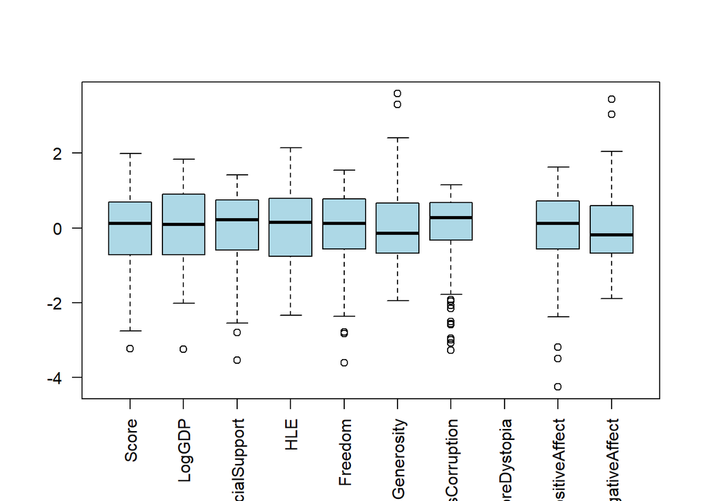

```r
# Don't forget to scale the data
boxplot(scale(data2), col = "lightblue", las = 2)
```

[output not shown]

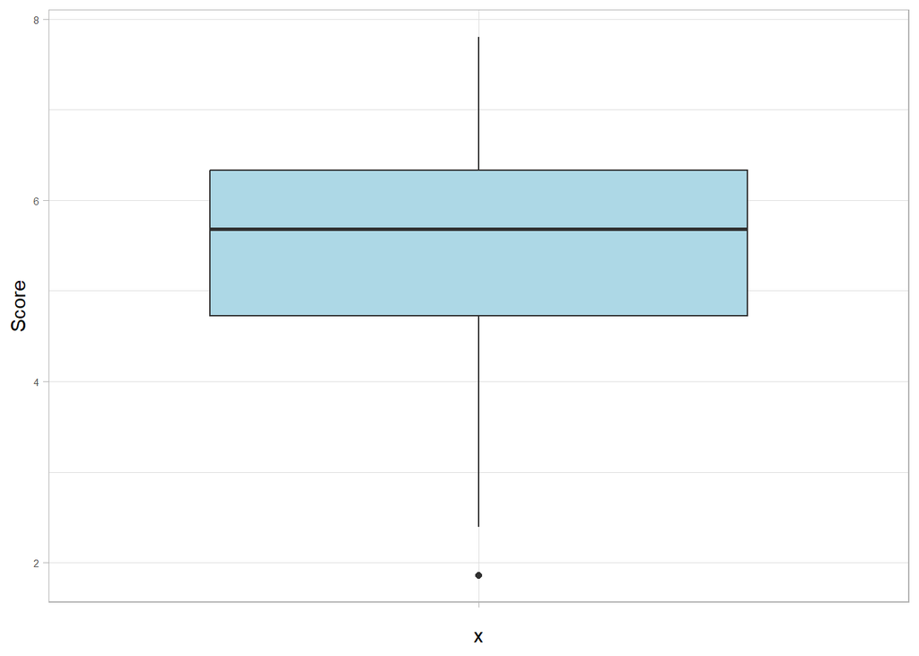

```r
par(mfrow=c(1,3))
# For "Score"
ggplot(data) +
  aes(x = "", y = Score) +
  geom_boxplot(fill = "lightblue") +
  labs(y = "Score") +
  theme_light()
```

[output not shown]

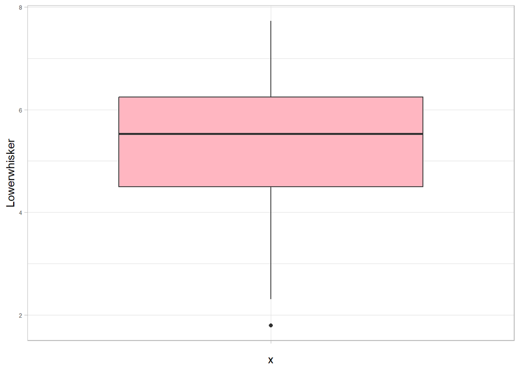

```r
# For "Lowerwhisker"
ggplot(data) +
  aes(x = "", y = Lowerwhisker) +
  geom_boxplot(fill = "lightpink") +
  labs(y = "Lowerwhisker") +
  theme_light()
```

[output not shown]

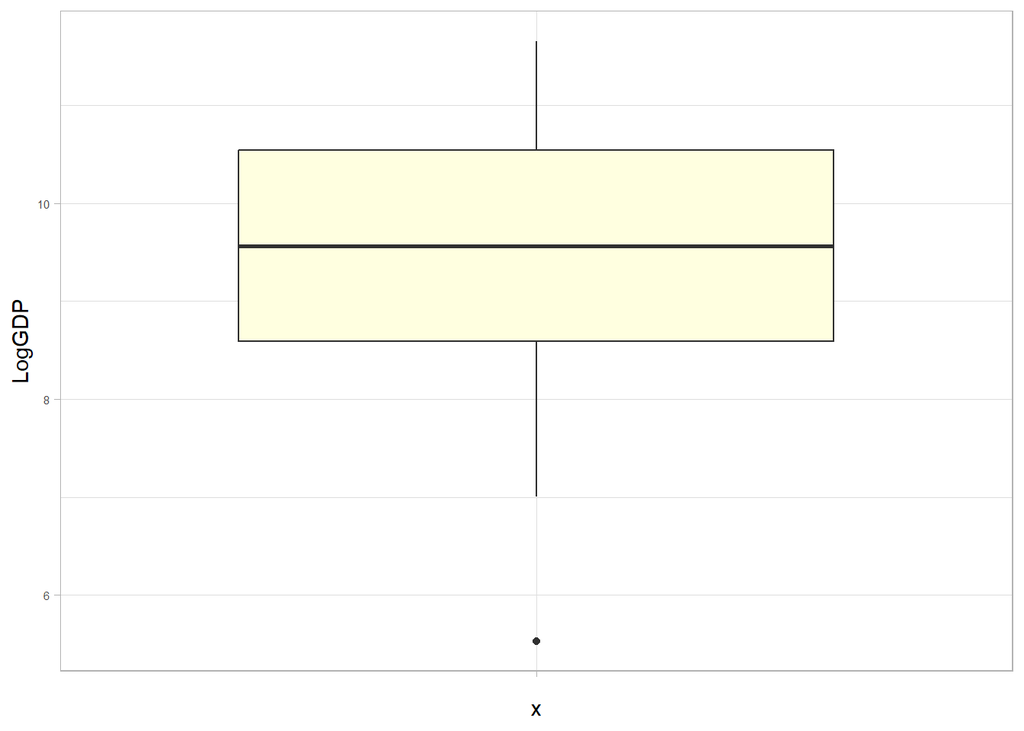

```r
# For "LogGDP"

ggplot(data) +
  aes(x = "", y = LogGDP) +
  geom_boxplot(fill = "lightyellow") +
  labs(y = "LogGDP") +
  theme_light()
```

## 2.5 Missing values

(lab1 data preprocessing)

Missing values, often denoted as NA (Not Available) or NaN (Not-a-Number), are placeholders used in data to represent the absence of a value or an unknown value for a particular observation or variable. They can have a significant impact on data analysis and modeling.

We can see the distribution of the NAs with the mice package

```r
sum(is.na(data2)) ## 31 missing values
```

```
## [1] 31
```

```r
md.pattern(data2)
```

[output not shown]

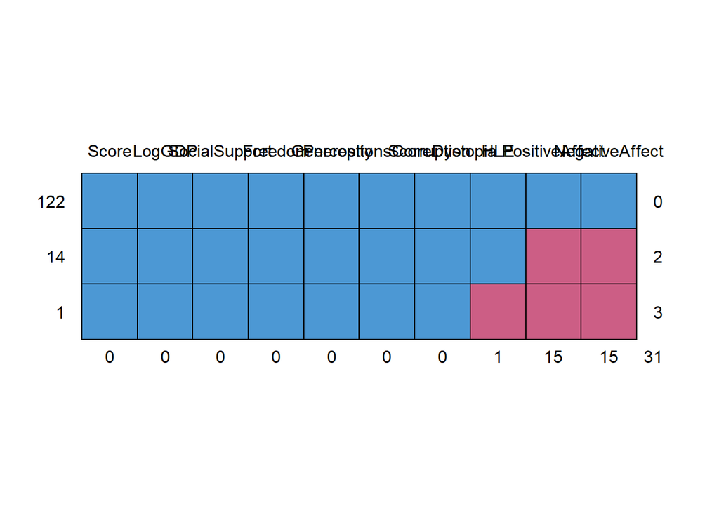

```
##     Score LogGDP SocialSupport Freedom Generosity PerceptionsCorruption
## 122     1      1             1       1          1                     1
## 14      1      1             1       1          1                     1
## 1       1      1             1       1          1                     1
##         0      0             0       0          0                     0
##     ScoreDystopia HLE PositiveAffect NegativeAffect
## 122             1   1              1              1  0
## 14              1   1              0              0  2
## 1               1   0              0              0  3
##                 0   1             15             15 31
```

```r
aggr(data2, number = TRUE, sortVars = TRUE, labels = names(data2),
     cex.axis = .7, gap = 1, ylab= c('Missing data','Pattern'))
```

[output not shown]

[output not shown]

[output not shown]

[output not shown]

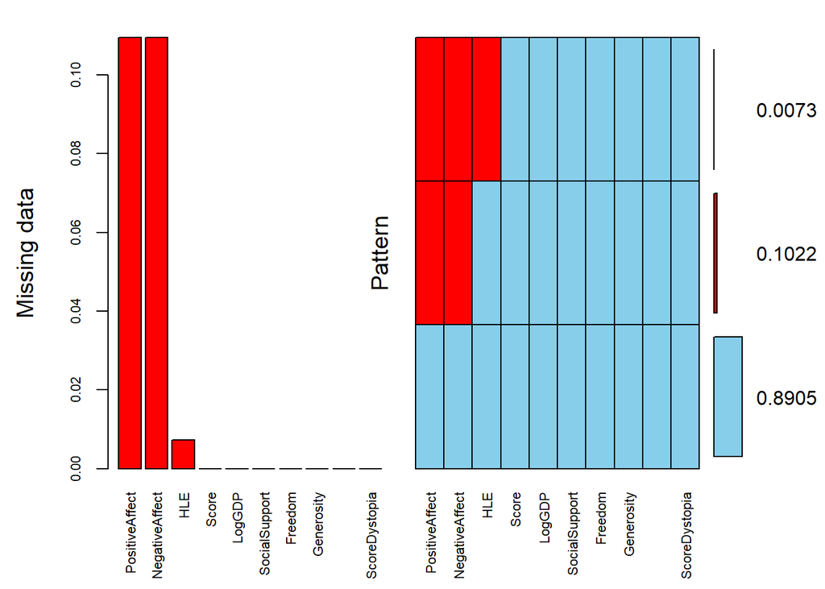

```
##
##  Variables sorted by number of missings:
##               Variable      Count
##         PositiveAffect 0.10948905
##         NegativeAffect 0.10948905
##                    HLE 0.00729927
##                  Score 0.00000000
##                 LogGDP 0.00000000
##          SocialSupport 0.00000000
##                Freedom 0.00000000
##             Generosity 0.00000000
##  PerceptionsCorruption 0.00000000
##          ScoreDystopia 0.00000000
```

The “mice” package in R is a powerful tool which is an iterative imputation method that replaces missing values with multiple imputations using a regression model. The imputed values are then used to estimate the missing values in the subsequent iteration until the convergence criteria are met. We are going to use Random Forest as method

```r
# If we want to remove the observation:   data[-which(rowSums(is.na(data)) ==5,)

imp <- mice(data2, method = 'rf', m = 7)
data2 = complete(imp)
summary(data2)
```

```
##      Score           LogGDP       SocialSupport         HLE
##  Min.   :1.859   Min.   : 5.527   Min.   :0.3413   Min.   :51.53
##  1st Qu.:4.724   1st Qu.: 8.591   1st Qu.:0.7220   1st Qu.:60.50
##  Median :5.684   Median : 9.567   Median :0.8271   Median :65.83
##  Mean   :5.540   Mean   : 9.450   Mean   :0.7990   Mean   :64.91
##  3rd Qu.:6.334   3rd Qu.:10.540   3rd Qu.:0.8960   3rd Qu.:69.35
##  Max.   :7.804   Max.   :11.660   Max.   :0.9825   Max.   :77.28
##     Freedom         Generosity        PerceptionsCorruption ScoreDystopia
##  Min.   :0.3816   Min.   :-0.254276   Min.   :0.1461        Min.   :1.778
##  1st Qu.:0.7239   1st Qu.:-0.073543   1st Qu.:0.6678        1st Qu.:1.778
##  Median :0.8005   Median : 0.001419   Median :0.7736        Median :1.778
##  Mean   :0.7874   Mean   : 0.022444   Mean   :0.7254        Mean   :1.778
##  3rd Qu.:0.8745   3rd Qu.: 0.117025   3rd Qu.:0.8459        3rd Qu.:1.778
##  Max.   :0.9614   Max.   : 0.531386   Max.   :0.9291        Max.   :1.778
##  PositiveAffect   NegativeAffect
##  Min.   :0.1789   Min.   :0.1161
##  1st Qu.:0.5901   1st Qu.:0.2327
##  Median :0.6628   Median :0.2747
##  Mean   :0.6513   Mean   :0.2924
##  3rd Qu.:0.7284   3rd Qu.:0.3465
##  Max.   :0.8344   Max.   :0.6067
```

```r
sum(is.na(data2))
```

```
## [1] 0
```

Now, we don’t have missing values anymore.

# 3 Visualization

Visualizations are a crucial part of EDA. Effective visualizations help you understand data distributions, trends, and anomalies. Along this section we are going to make some questions and use a plot to answer them.

## 3.1 Univariate: Dimension 1

We have already seen the boxplots.

**1)** What is the distribution of the “Score”? In this case we are going to generate a histogram that shows the distribution of happiness scores.

[output not shown]

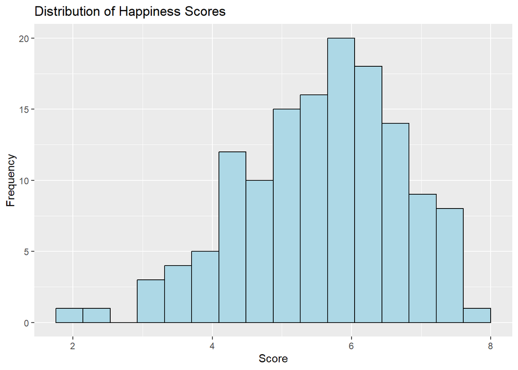

```r
ggplot(data, aes(x = Score)) +
  geom_histogram(binwidth = 0.39, fill = "lightblue", color = "black") +
  labs(title = "Distribution of Happiness Scores",
       x = "Score",
       y = "Frequency")
```

```r
sum(which(data2$Score < 2))
```

```
## [1] 137
```

```r
# We have 2 observations with a really low score
r <- which(data2$Score < 3)
n <- data$Country[r]
print(n)
```

```
## [1] "Lebanon"     "Afghanistan"
```

Now, I think that these observations are not outliers as in “Lebanon” and “Afghanistan” is understandable a low score because of their bad situation.

[output not shown]

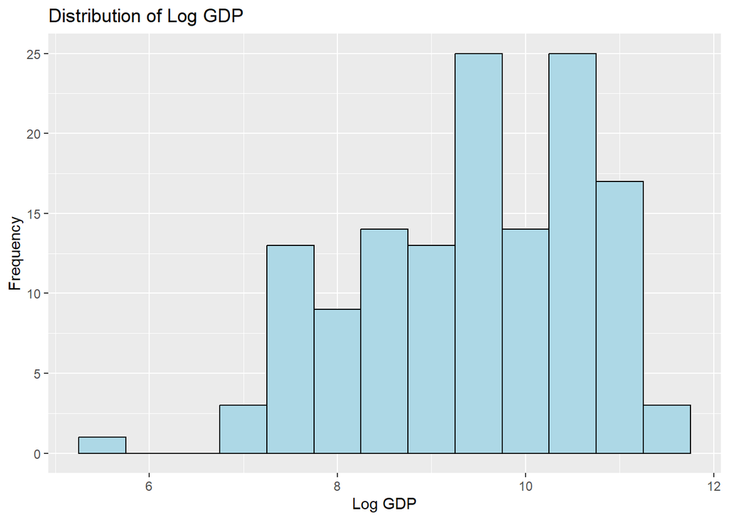

```r
# Create a histogram for the "LogGDP" variable
ggplot(data, aes(x = LogGDP)) +
  geom_histogram(binwidth = 0.5, fill = "lightblue", color = "black") +
  labs(title = "Distribution of Log GDP",
       x = "Log GDP",
       y = "Frequency")
```

```r
print(data$Country[which(data2$LogGDP < 6)])  # Venezuela
```

```
## [1] "Venezuela"
```

[output not shown]

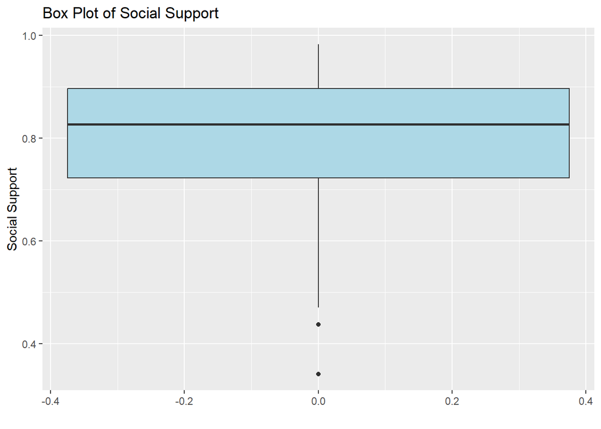

```r
ggplot(data, aes(y = SocialSupport)) +
  geom_boxplot(fill = "lightblue") +
  labs(title = "Box Plot of Social Support",
       x = "",
       y = "Social Support")
```

As we want to know weather the wealthy a contry is has an impact on the level of happines, we are going to make an scatterplot to visualize the relationship

[output not shown]

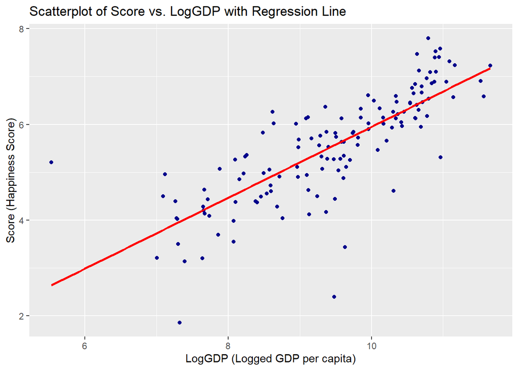

```r
ggplot(data2, aes(x = LogGDP, y = Score)) +
  geom_point(color = "darkblue") +
  geom_smooth(method = "lm", se = FALSE, color = "red") +
  labs(title = "Scatterplot of Score vs. LogGDP with Regression Line",
       x = "LogGDP (Logged GDP per capita)",
       y = "Score (Happiness Score)")
```

Without any doubt, we can see a strong positive linear relationship between GDP and Score.

Multiple scatterplots:

```r
# When applying ggcorr() -> obtain Warning: the standard deviation is zero.
# a standard deviation of zero means that one or more variables in our dataset have no variability because all of # their values are the same. So, we check this
vars_0sd = colnames(data2)[apply(data2, 2, sd) == 0]
# We realise that "ScoreDystopia" takes always the value 1.777825. Therefore,I am going to exclude it as it won't provide meaningful correlation values.

data2 =  data2 %>% dplyr::select(-ScoreDystopia)

ggcorr(data2, label = T)
```

[output not shown]

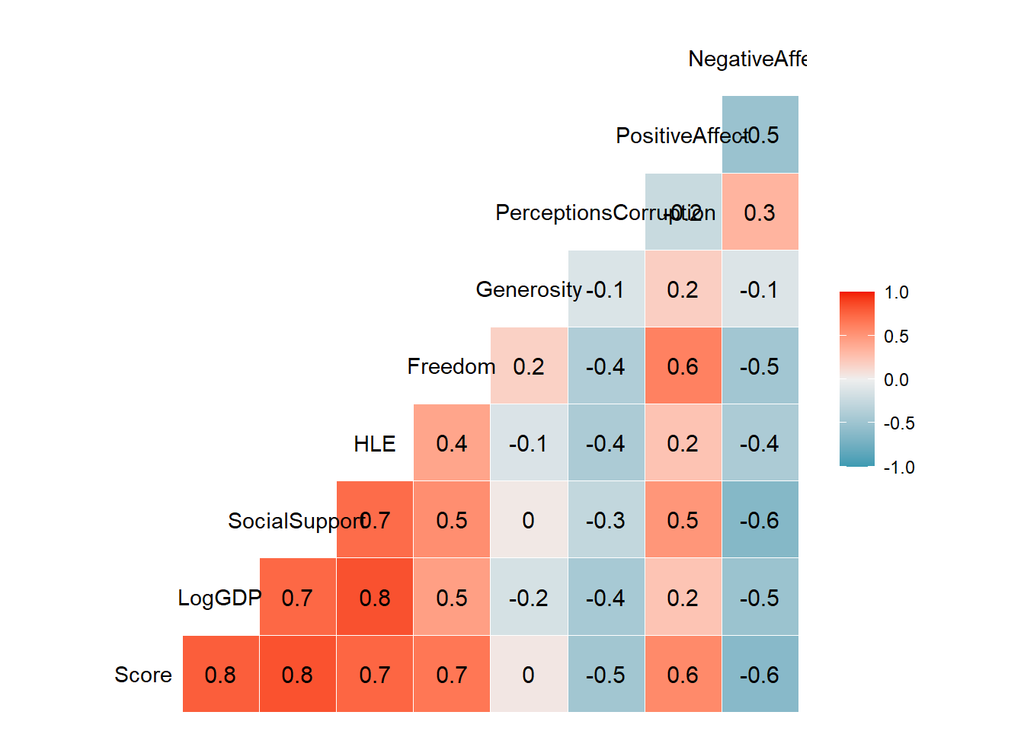

[output not shown]

[output not shown]

[output not shown]

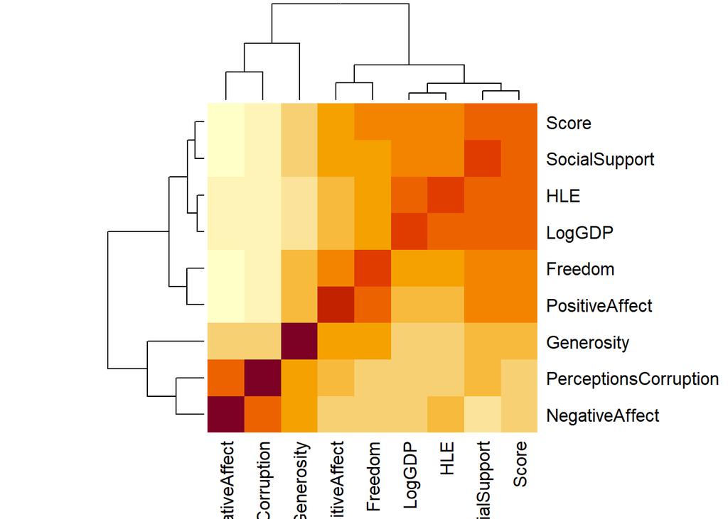

```r
heatmap(cor(data2))
```

We can see that the hapiness score is highly positive related with GDP and SocialSupport, and negative related with PerceptionsCorruption and NegativeAffect. These are expected results. However, I find it surprising that Score and Generosity are independent.

Let’s see the relation between each pair of our variables

[output not shown]

[output not shown]

[output not shown]

[output not shown]

[output not shown]

[output not shown]

[output not shown]

[output not shown]

[output not shown]

[output not shown]

[output not shown]

[output not shown]

[output not shown]

[output not shown]

[output not shown]

[output not shown]

[output not shown]

[output not shown]

[output not shown]

[output not shown]

[output not shown]

[output not shown]

[output not shown]

[output not shown]

[output not shown]

[output not shown]

[output not shown]

[output not shown]

[output not shown]

[output not shown]

[output not shown]

[output not shown]

[output not shown]

[output not shown]

[output not shown]

[output not shown]

[output not shown]

[output not shown]

[output not shown]

[output not shown]

[output not shown]

[output not shown]

[output not shown]

[output not shown]

[output not shown]

[output not shown]

[output not shown]

[output not shown]

[output not shown]

[output not shown]

[output not shown]

[output not shown]

[output not shown]

[output not shown]

[output not shown]

[output not shown]

[output not shown]

[output not shown]

[output not shown]

[output not shown]

[output not shown]

[output not shown]

[output not shown]

[output not shown]

[output not shown]

[output not shown]

[output not shown]

[output not shown]

[output not shown]

[output not shown]

[output not shown]

[output not shown]

[output not shown]

[output not shown]

[output not shown]

[output not shown]

[output not shown]

[output not shown]

[output not shown]

[output not shown]

[output not shown]

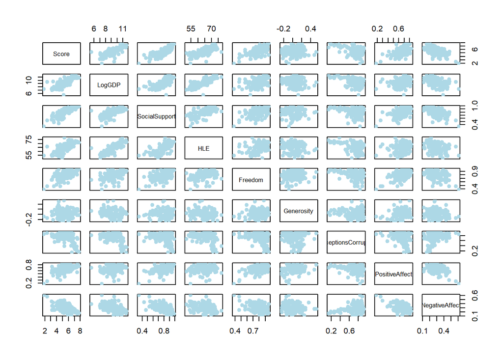

```r
pairs(data2, pch = 19, col = "lightblue")
```

# 4 PCA

(lab PCA)

Principal Component Analysis (PCA) is a widely used statistical technique for dimensionality reduction and data transformation. PCA is employed when dealing with high-dimensional data, where each observation is described by multiple variables. It allows to identify and highlight the most important patterns or directions in the data. It creates new variables (principal components) that are linear combinations of the original variables, capturing the maximum variance in the data.

It is important to remember that PCA is sensitive to the scaling of the data. When variables have different scales, those with larger scales will contribute more to the overall variance. This can lead to the PCA being dominated by variables with large scales, while variables with smaller scales may have limited influence on the principal components.

```r
pca = prcomp(data2, scale=T)
# pca = princomp(nba, cor=T) # the same, but using SVD instead of eigen decomposition
summary(pca)
```

```
## Importance of components:
##                           PC1    PC2     PC3     PC4     PC5     PC6     PC7
## Standard deviation     2.1815 1.1750 0.93059 0.81871 0.73010 0.58083 0.43591
## Proportion of Variance 0.5288 0.1534 0.09622 0.07448 0.05923 0.03748 0.02111
## Cumulative Proportion  0.5288 0.6822 0.77841 0.85288 0.91211 0.94960 0.97071
##                            PC8     PC9
## Standard deviation     0.38588 0.33869
## Proportion of Variance 0.01655 0.01275
## Cumulative Proportion  0.98725 1.00000
```

## 4.1 Number of PCA components

We are using **screeplot** to generate a PCA scree plot that visually displays the explained variance for each principal component. This visualization aids in pinpointing the ‘elbow point,’ where the explained variance curve starts to stabilize, providing insights into the dimensionality of the data.

For that, we use fviz_screeplot() function from factoextra package:

[output not shown]

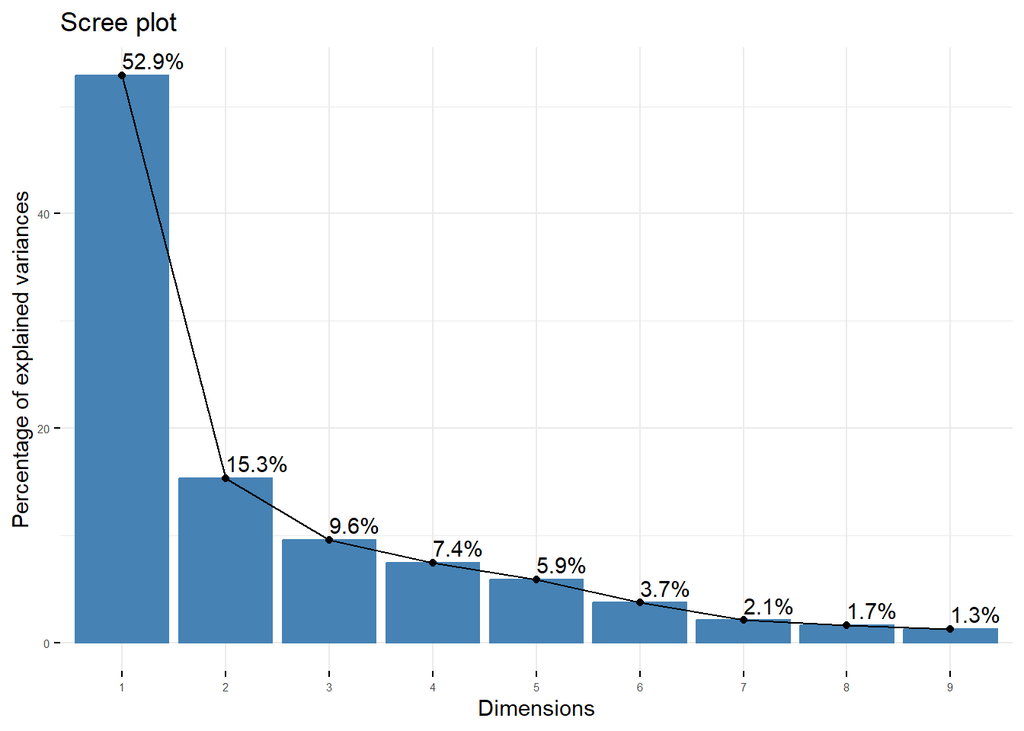

```r
fviz_screeplot(pca, addlabels = TRUE)
```

We decide to take 3 components.

## 4.2 Interpretation of the Components

Interpreting the components in a Principal Component Analysis (PCA) involves understanding the relationship between the original variables and the principal components, which are linear combinations of the original variables.

We are creating a bar plot for the first principal component’s loadings in a PCA analysis. We need to extract the loadings which represent the strength and direction of each original variable’s contribution to the first component.

First, we are going to plot the **square loadings** which indicate the proportion of variance in each original variable that is explained by the associated principal component. Higher squared loadings indicate that the variable contributes more to that component.

[output not shown]

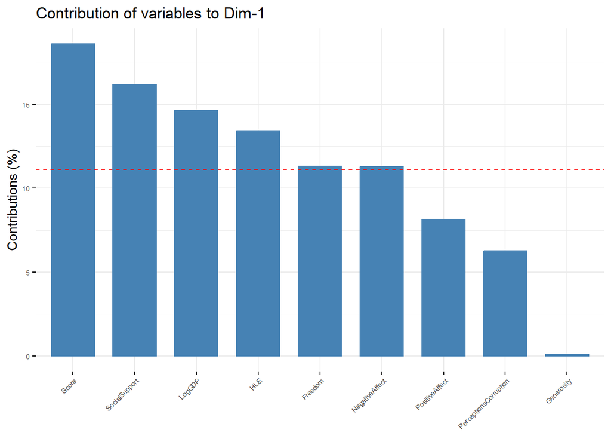

```r
fviz_contrib(pca, choice = "var", axes = 1)
```

We see that “Score” is the one which most contributes as expected. On the other hand “Generosity” is the one which contributes less as it was independent to Score.

Now, let’s analyze the Direction of Component Loadings. For that, we need to examine the signs of the component loadings. Positive loadings indicate a positive relationship with the component, while negative loadings indicate a negative relationship.

[output not shown]

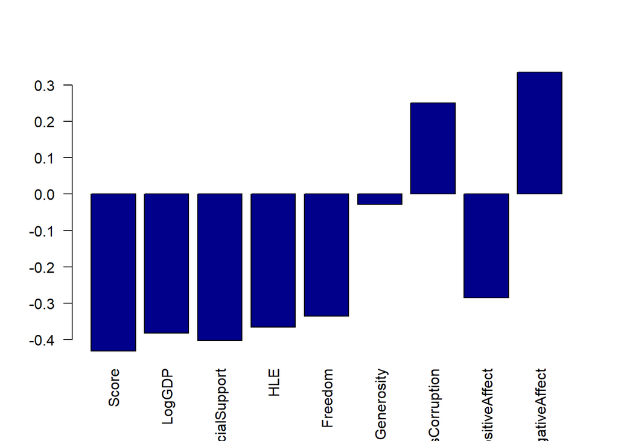

```r
barplot(pca$rotation[,1], las=2, col="darkblue")
```

We see that “PerceptionsCorruption” and “NegativeAffect” have a positive effect in PC1 whereas the other variables a negative effect. Therefore, we can interpret this PC1 has the “unhapiness of the countries”

pca$x[,1] gives you a vector of the PC1 scores for all the data points in your analysis. These scores represent how each observation contributes to PC1 and can be used for various purposes, including ranking or analyzing the data based on this component. Now we can rank the Countries by their PC1 scores: level of unhappiness:

```r
# Take the first 5 countries which have a high value of the scores but with NEGATIVE sign which  indicates a negative association with PC1. These countries have less level of unhappiness.
rows_first = order(pca$x[,1])[1:5]
country_names[rows_first]
```

```
## [1] "Finland" "Denmark" "Sweden"  "Norway"  "Iceland"
```

```r
# Take the first 5 countries which have a high value of the scores but with POSITIVE sign which  indicates a positive association with PC1. These countries have higer level of unhappiness.
rows_last <- tail(order(pca$x[,1]), 5)
country_names[rows_last]
```

```
## [1] "Comoros"      "Gambia"       "Sierra Leone" "Lebanon"      "Afghanistan"
```

We do the same for PC2

[output not shown]

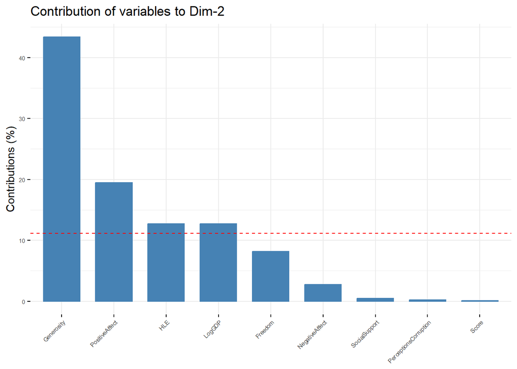

```r
fviz_contrib(pca, choice = "var", axes = 2)
```

In this case, we see that the contribution of “Score” is really low, so we are not interpreting this component relating it with level of hapiness. Now, we focus on “Generosity” which is the variable that contribute most.

[output not shown]

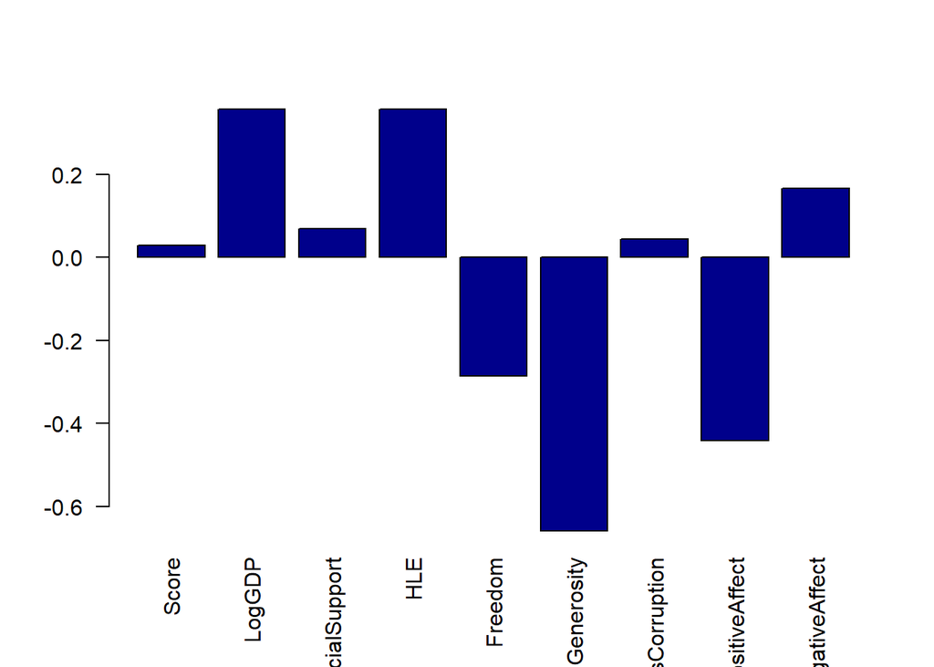

```r
barplot(pca$rotation[,2], las=2, col="darkblue")
```

We can see that when PC2 decreases with “Generosity” and “PositiveAffect” while it increases with “LogGDP” and ” HLE”. We could interpret this as the countries with higher GDP and Healthy Life Expectancy tend to be less generous and have less laugh, enjoyment (positiveAffect)

### 4.2.1 **3º Component**

[output not shown]

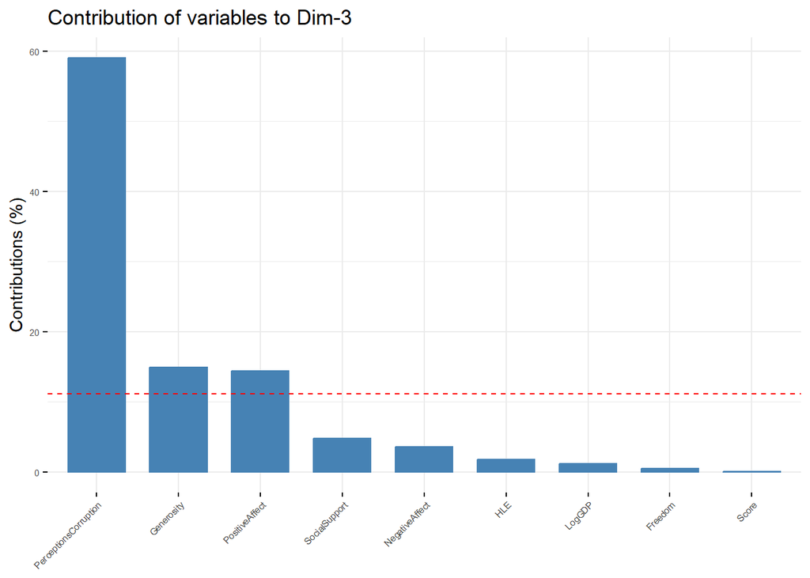

```r
fviz_contrib(pca, choice = "var", axes = 3)
```

Here, “PerceptionsCorruption” is now our target.

[output not shown]

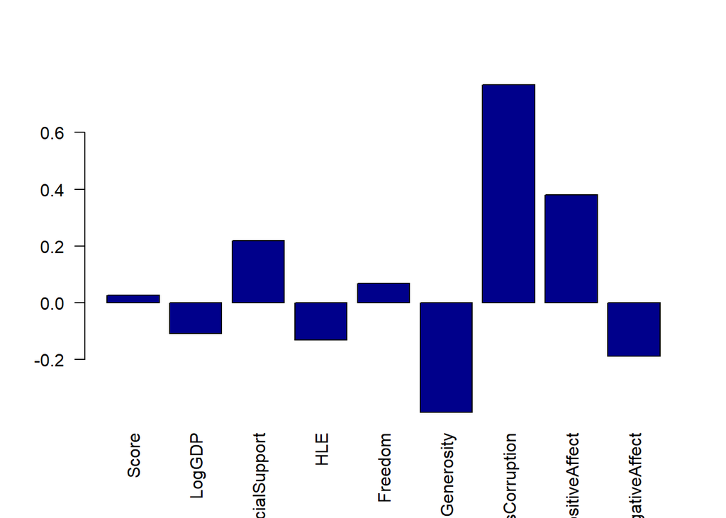

```r
barplot(pca$rotation[,3], las=2, col="darkblue")
```

### 4.2.2 Biplot

A biplot displays both the observations (data points) and the variables (original features), allowing you to visualize the relationships and associations between them in a reduced-dimensional space. The variables are represented by arrows that point in the direction of increasing values. The length of these arrows represents the strength of the relationship between the variables and the principal components. Longer arrows indicate stronger relationships.

[output not shown]

[output not shown]

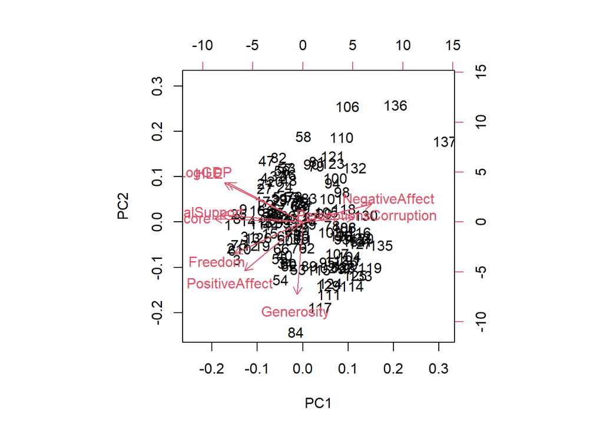

```r
biplot(pca)
```

In this case, it is not very useful because of the high amount of countries

We can make a plot that displays the contributions of each variable to the principal components. Variables that make a stronger contribution to a component will be highlighted in the plot, helping you identify which variables are most influential in shaping the PCA results.

[output not shown]

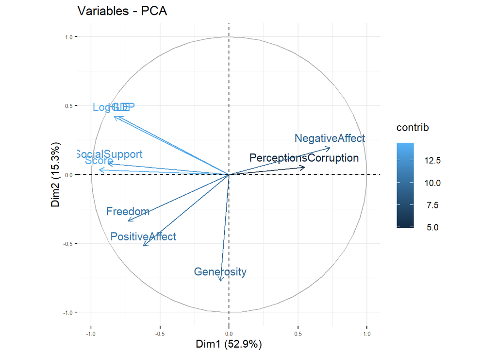

```r
fviz_pca_var(pca, col.var = "contrib")
```

As we have said previously, we see we can see a positive contribution of “PerceptionsCorruption” and “NegativeAffect” on PC1 (Dim1), as well as “LogGDP” and “HLE” on PC2 (Dim2).

[output not shown]

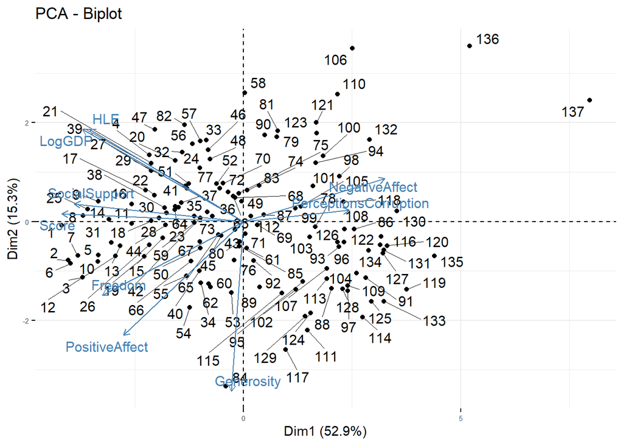

```r
fviz_pca_biplot(pca, repel = TRUE)
```

With repel = TRUE, the labels of observations and variables in the biplot will automatically adjust their positions to avoid overlapping, making it easier to interpret and visualize the relationships between observations and variables in the reduced-dimensional space when we have a large dataset.

## 4.3 The Scores

Remember, for the $j$-th principal component: $Z_j = X a_j$, $a_j$ denotes the loadings, and $Z_j$ denotes the scores

[output not shown]

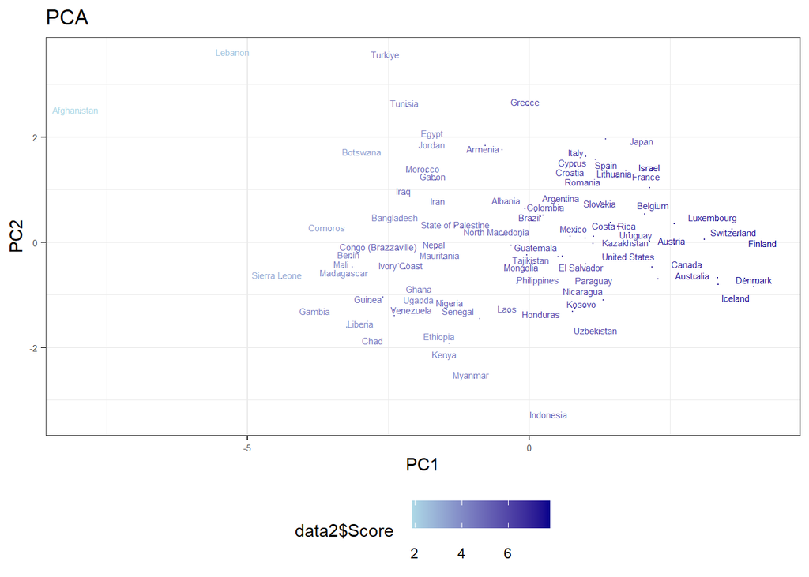

```r
data.frame(z1=-pca$x[,1],z2=pca$x[,2]) %>%
  ggplot(aes(z1,z2,label=country_names,color=data2$Score)) + geom_point(size=0) +
  labs(title="PCA", x="PC1", y="PC2") +
  theme_bw() + scale_color_gradient(low="lightblue", high="darkblue")+theme(legend.position="bottom") + geom_text(size=2, hjust=0.6, vjust=0, check_overlap = TRUE)
```

[output not shown]

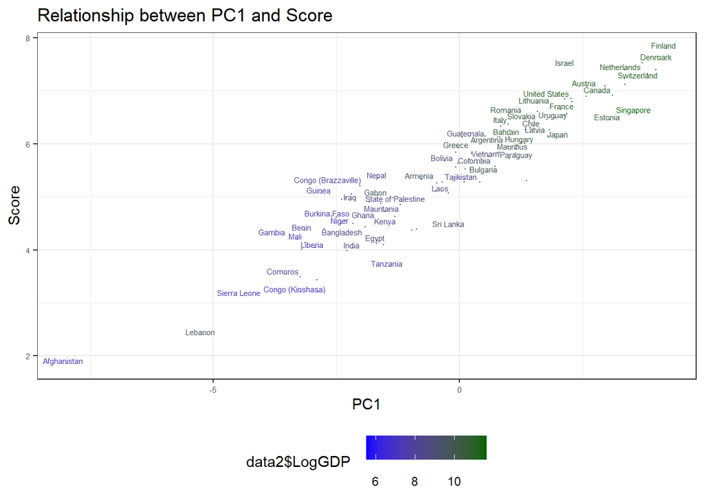

```r
data.frame(z1=-pca$x[,1],z2=data2$Score) %>%
  ggplot(aes(z1,z2,label=country_names,color=data2$LogGDP)) + geom_point(size=0) +
  labs(title="Relationship between PC1 and Score", x="PC1", y="Score") +
  theme_bw() + scale_color_gradient(low="blue", high="darkgreen")+theme(legend.position="bottom") + geom_text(size=2, hjust=0.6, vjust=0, check_overlap = TRUE)
```

We can see a clear linear relationship

# 5 Factor Analysis

(Based on lab FA)

Factor Analysis is a statistical method used for data reduction and dimensionality reduction. The goal of Factor Analysis is to identify a smaller number of latent factors that can explain the correlations or covariations between the observed variables. It’s common to perform factor rotation to make the factors more interpretable. In our case we are using “varimax”

```r
fa <- factanal(data2, factors = 4, rotation="varimax", scores="Bartlett", lower = 0.01)
fa
```

```
##
## Call:
## factanal(x = data2, factors = 4, scores = "Bartlett", rotation = "varimax",     lower = 0.01)
##
## Uniquenesses:
##                 Score                LogGDP         SocialSupport
##                 0.105                 0.092                 0.010
##                   HLE               Freedom            Generosity
##                 0.211                 0.370                 0.847
## PerceptionsCorruption        PositiveAffect        NegativeAffect
##                 0.624                 0.344                 0.010
##
## Loadings:
##                       Factor1 Factor2 Factor3 Factor4
## Score                  0.731   0.476   0.304   0.203
## LogGDP                 0.757   0.504  -0.177   0.222
## SocialSupport          0.915           0.265   0.281
## HLE                    0.756   0.437  -0.122   0.104
## Freedom                0.381   0.447   0.526
## Generosity                             0.377
## PerceptionsCorruption -0.197  -0.559          -0.125
## PositiveAffect         0.269   0.241   0.699   0.190
## NegativeAffect        -0.335  -0.235  -0.295  -0.858
##
##                Factor1 Factor2 Factor3 Factor4
## SS loadings      2.893   1.303   1.212   0.980
## Proportion Var   0.321   0.145   0.135   0.109
## Cumulative Var   0.321   0.466   0.601   0.710
##
## Test of the hypothesis that 4 factors are sufficient.
## The chi square statistic is 7.62 on 6 degrees of freedom.
## The p-value is 0.267
```

Let’s try to perform Factor Analysis with 3 factors

```r
fa2 <- factanal(data2, factors = 3, rotation="varimax", scores="Bartlett", lower = 0.01)
fa2
```

```
##
## Call:
## factanal(x = data2, factors = 3, scores = "Bartlett", rotation = "varimax",     lower = 0.01)
##
## Uniquenesses:
##                 Score                LogGDP         SocialSupport
##                 0.107                 0.105                 0.010
##                   HLE               Freedom            Generosity
##                 0.213                 0.383                 0.848
## PerceptionsCorruption        PositiveAffect        NegativeAffect
##                 0.623                 0.332                 0.511
##
## Loadings:
##                       Factor1 Factor2 Factor3
## Score                  0.738   0.517   0.284
## LogGDP                 0.754   0.543  -0.179
## SocialSupport          0.957   0.112   0.247
## HLE                    0.730   0.479  -0.155
## Freedom                0.381   0.462   0.508
## Generosity                             0.383
## PerceptionsCorruption -0.193  -0.575
## PositiveAffect         0.308   0.259   0.712
## NegativeAffect        -0.546  -0.248  -0.360
##
##                Factor1 Factor2 Factor3
## SS loadings      3.141   1.478   1.249
## Proportion Var   0.349   0.164   0.139
## Cumulative Var   0.349   0.513   0.652
##
## Test of the hypothesis that 3 factors are sufficient.
## The chi square statistic is 16.33 on 12 degrees of freedom.
## The p-value is 0.177
```

## 5.1 Interpretation

Now, we create a dataframe that combines the factor loadings and uniquenesses into a single data frame. Factor loading is a measure of the relationship between each observed variable and the extracted factors. High factor loadings indicate a strong relationship between the variable and the factor.

Communality represents the proportion of variance in an observed variable that is explained by the retained factors. High communality values suggest that the factor model explains a large portion of the variable’s variance. The uniqueness is complementary to communality (= 1-Communality) and it refers to the proportion of variance in an observed variable that is unique or specific to that variable and not explained by the underlying factors extracted by the analysis.

```r
cbind(fa2$loadings, fa2$uniquenesses)
```

```
##                           Factor1     Factor2     Factor3
## Score                  0.73810749  0.51679527  0.28400635 0.1074599
## LogGDP                 0.75368775  0.54318352 -0.17890222 0.1049006
## SocialSupport          0.95743063  0.11182498  0.24663961 0.0100000
## HLE                    0.73046279  0.47858162 -0.15544354 0.2132181
## Freedom                0.38076746  0.46247854  0.50842715 0.3826284
## Generosity            -0.05727022 -0.04386745  0.38320639 0.8479409
## PerceptionsCorruption -0.19277640 -0.57452666 -0.09843363 0.6230780
## PositiveAffect         0.30826212  0.25878534  0.71157944 0.3316556
## NegativeAffect        -0.54579368 -0.24770690 -0.36004049 0.5111276
```

```r
par(mfrow=c(3,1))
barplot(fa2$loadings[,1], names=F, las=2, col="darkblue", ylim = c(-1, 1))
```

[output not shown]

```r
barplot(fa2$loadings[,2], names=F, las=2, col="darkblue", ylim = c(-1, 1))
```

[output not shown]

[output not shown]

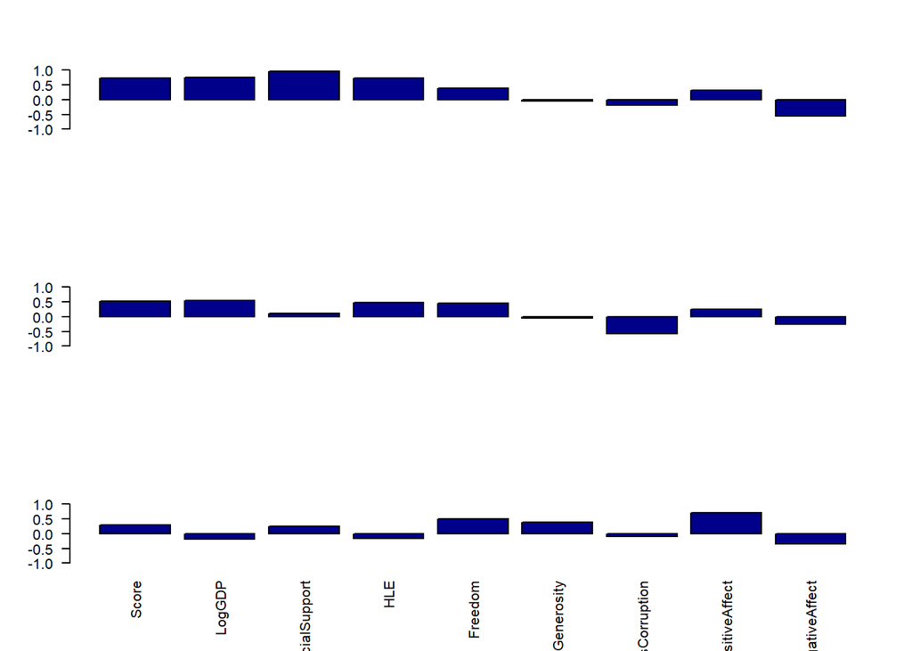

```r
barplot(fa2$loadings[,3], las=2, col="darkblue", ylim = c(-1, 1))
```

Using the previous plots and dataframe we can associate to the original variavles to the factors Factor1: “Score”, “LogGDP”, “SocialSupport”, “HLE” and negatively “NegativeAffect” Factor2: Negative “PerceptionsCorruption” Factor3: “Freedom”, “Generosity”, “PositiveAffect”

With this, we can interpret: - Factor 1 appears to represent a factor related to overall well-being, happiness, and life quality. - Factor 2 appears to represent a factor related to the absence of perceptions of corruption. - Factor 3 appears to represent a factor related to positive social attributes or attitudes.

## 5.2 Scores

Factor scores are values that represent the degree to which each observation in a dataset exhibits certain characteristics or behaviors associated with underlying latent factors.

[output not shown]

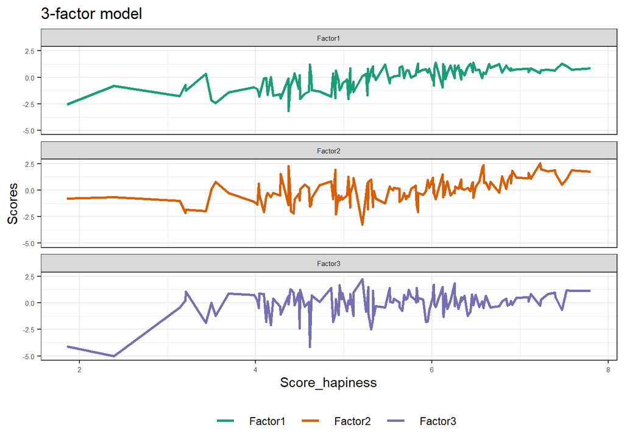

```r
factor.df <- data.frame(Score_hapiness = data2$Score, fa2$scores)

# Reshape the data to long format using gather
factor.df <- factor.df %>%
  gather("factor", "score", -Score_hapiness)

# Create the ggplot visualization
factor.df %>%
  ggplot(aes(x = Score_hapiness, y = score, color = factor)) +
  geom_line(size = 1) +
  theme_bw() +
  theme(legend.position = "bottom") +
  scale_color_brewer(palette = "Dark2") +
  facet_wrap(~factor, ncol = 1) +
  labs(title = "3-factor model", x = "Score_hapiness", y = "Scores", col = "")
```

Factor 1 is associated with well-being. We see a positive trend for Factor 1, this suggests that higher “Score_happiness” values are associated with higher well-being.

Factor 2 is associated absence of perceptions of corruption. We see a positive trend for Factor 2, this suggests that higher “Score_happiness” values are associated no perception of corruption.

# 6 Clustering

(Based on labs of clustering)

Clustering is a machine learning and data analysis technique that involves grouping similar data points or objects together based on certain characteristics or features. The goal of clustering is to discover underlying patterns or structures in data, which can be helpful for various purposes, such as data exploration, pattern recognition, and decision-making.

In our case, clustering can help segment countries into distinct groups based on their happiness-related characteristics.

## 6.1 K-Means

We are going to try the number of clusters as geographical regions as they might naturally lead to clusters. It could be a possibility that countries within the same continent tend to have similar happiness profiles. However, we will compute the number of clusters in a more sophiticated way later.

Here, we apply the K-Means clustering algorithm to our data. We scales the data. centers=k specifies the number of clusters, and nstart=1000 sets the number of times the algorithm will attempt to find the optimal cluster centers. The results are stored in the fit object. “groups” indicates which cluster each data point belongs to.

Then, we create a bar plot showing the distribution of data points in each cluster. The table(groups) function counts the number of data points in each cluster,

[output not shown]

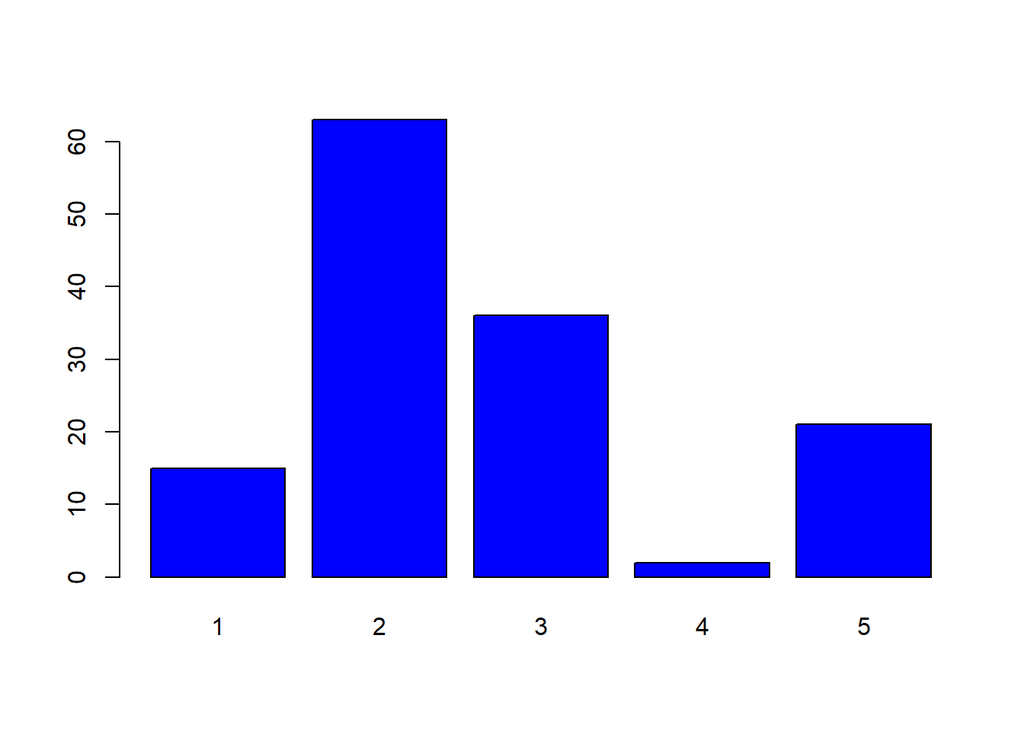

```r
set.seed(123) # In order to obtain the same clusters for explanations
k = 5
# nstart: make the random process nstart times,
fit = kmeans(scale(data2), centers=k, nstart=1000)
groups = fit$cluster

barplot(table(groups), col="blue")
```

```r
# Heuristic because we select the first centroids randomly
```

We notice an imbalance in the sizes of the clusters

### 6.1.1 Interpretation of centers

1. We are visualizing the cluster centers, which represent the mean values of the observations within each cluster. In order to compare and analyze the cluters it is better to plot them together.

```r
centers=fit$centers
# Centers are the mean value of the observations in the group. It contains the mean for each feature
par(mfrow=c(2,3))

barplot(centers[1,], las=2, col="lightblue", main = "Cluster 1")
```

[output not shown]

```r
barplot(centers[2,], las=2, col="lightblue",main = "Cluster 2")
```

[output not shown]

```r
barplot(centers[3,], las=2, col="lightblue", main = "Cluster 3")
```

[output not shown]

```r
barplot(centers[4,], las=2, col="lightblue", main = "Cluster 4")
```

[output not shown]

```r
barplot(centers[5,], las=2, col="lightblue", main = "Cluster 5")
```

[output not shown]

```r
# Difficult to understand as I could not say in which group is Spain
```

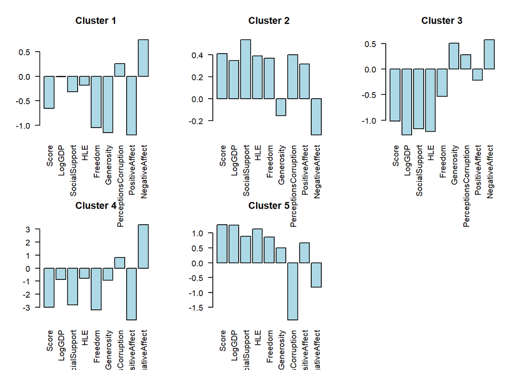

These visualizations can provide insights into how each cluster differs in terms of the feature values. We can compare the bar plots to understand the characteristics and differences of the clusters. However, it is not very easy to understand as we cannot see which cluster corresponds to each country.